# Лабораторная работа №15

Администрирование локальных сетей

Ибрахим Мохсейн Алькамаль

1032225432@rudn.ru

Российский университет дружбы народов

2026-05-23

# Информация

## Докладчик

- Ибрахим Мохсейн Алькамаль
- Российский университет дружбы народов
- [GitHub](https://github.com/Ebrahimalkamal2027)

# Цель работы

- Настройка динамической маршрутизации между территориями организации

# Выполнение лабораторной работы

## Настройка OSPF на маршрутизаторе сети «Донская»

- Включён процесс OSPF на маршрутизаторе сети «Донская»
- Назначен Router ID `10.128.254.1`
- Сети `10.0.0.0/8` добавлены в `area 0`

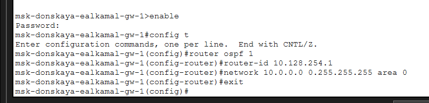

Рисунок 1: Настройка OSPF на маршрутизаторе сети «Донская»

## Проверка состояния OSPF и таблицы маршрутизации

- Выполнена проверка состояния OSPF
- Подтверждён запуск процесса OSPF
- Проверена таблица маршрутизации
- Обнаружен маршрут к сети Сочи `10.130.0.0/16`

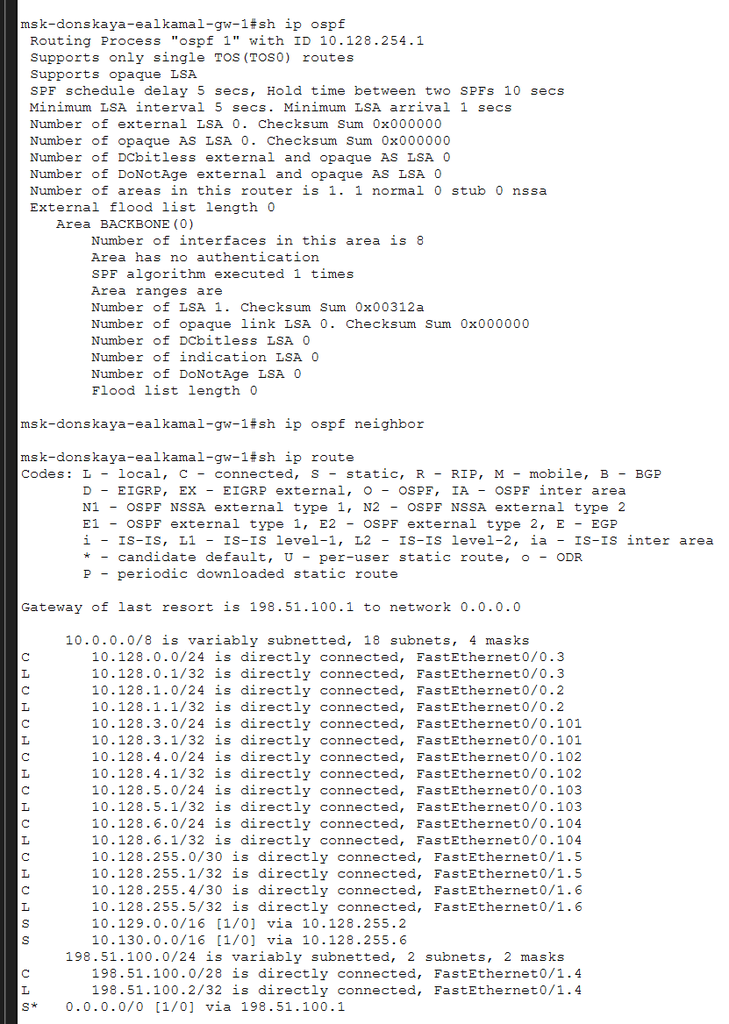

Рисунок 2: Проверка состояния OSPF и таблицы маршрутизации

## Настройка OSPF на маршрутизаторе сети 42-го квартала

- Настроен OSPF на маршрутизаторе сети 42-го квартала
- Назначен Router ID `10.128.254.2`
- Сети добавлены в `area 0`

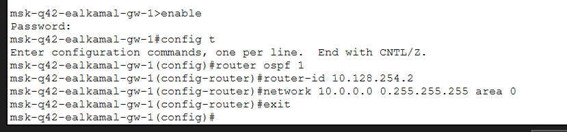

Рисунок 3: Настройка OSPF на маршрутизаторе сети 42-го квартала

## Настройка OSPF на маршрутизаторе сети общежития

- Настроен OSPF на маршрутизаторе сети общежития
- Назначен Router ID `10.128.254.3`
- Выполнена публикация сетей в `area 0`

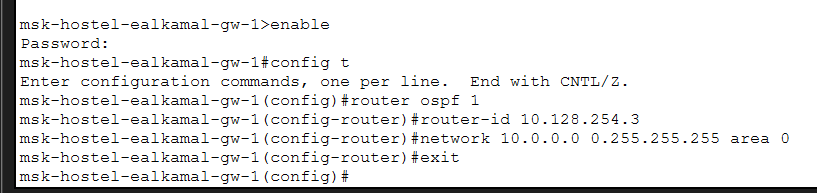

Рисунок 4: Настройка OSPF на маршрутизаторе сети общежития

## Настройка OSPF на маршрутизаторе филиала в Сочи

- Настроен OSPF на маршрутизаторе филиала в Сочи
- Назначен Router ID `10.128.254.4`
- Локальные сети добавлены в `area 0`

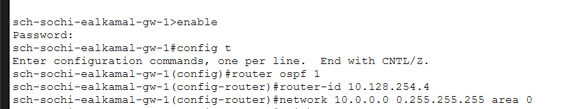

Рисунок 5: Настройка OSPF на маршрутизаторе филиала в Сочи

## Создание VLAN 7 на коммутаторе провайдера

- Создан VLAN 7 `q42-sochi` на коммутаторе провайдера
- Активирован интерфейс `Vlan7`

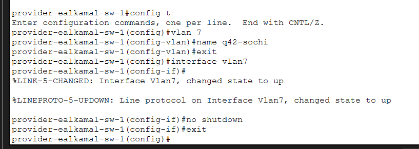

Рисунок 6: Создание VLAN 7 на коммутаторе провайдера

# Настройка подинтерфейса VLAN 7 на маршрутизаторе 42-го квартала

- Создан подинтерфейс `FastEthernet0/1.7`
- Настроена инкапсуляция IEEE 802.1Q
- Назначен IP-адрес `10.128.255.9/30`
- Добавлено описание `sochi`

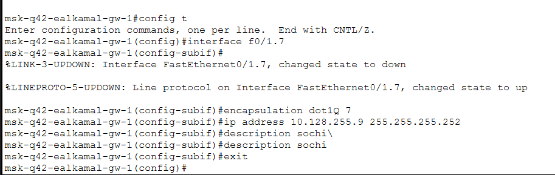

Рисунок 7: Настройка подинтерфейса VLAN 7 на маршрутизаторе 42-го квартала

## Создание VLAN 7 на коммутаторе филиала в Сочи

- Создан VLAN 7 `q42-sochi` на коммутаторе филиала в Сочи
- Активирован интерфейс `Vlan7`
- Интерфейс переведён в состояние `up/up`

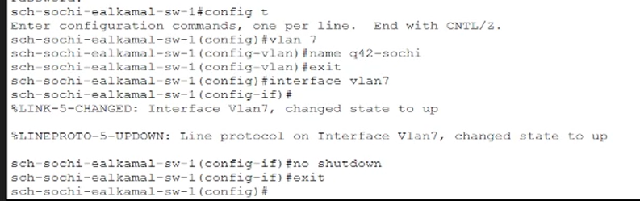

Рисунок 8: Создание VLAN 7 на коммутаторе филиала в Сочи

## Настройка OSPF и подинтерфейса VLAN 7 в филиале Сочи

- Настроен OSPF на маршрутизаторе филиала в Сочи
- Создан подинтерфейс `FastEthernet0/0.7`
- Настроена инкапсуляция IEEE 802.1Q
- Назначен IP-адрес `10.128.255.10/30`
- Добавлено описание `q42`

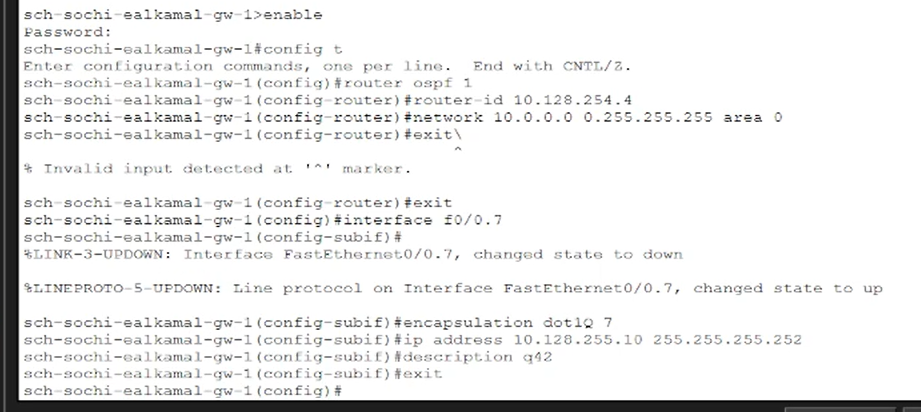

Рисунок 9: Настройка OSPF и подинтерфейса VLAN 7 на маршрутизаторе филиала в Сочи

# Выводы